# Results: Exercise 4 Single Factor Experiments CRD.sas

Example Oneway ANOVA Portland Cement Data

| Obs | PORTLAND_CEMENT | OBS | TENSILE_STRENGTH |
| --- | --- | --- | --- |
| 1 | 1 | 1 | 3129 |
| 2 | 1 | 2 | 3000 |
| 3 | 1 | 3 | 2865 |
| 4 | 1 | 4 | 2890 |
| 5 | 2 | 5 | 3200 |
| 6 | 2 | 6 | 3300 |
| 7 | 2 | 7 | 2975 |
| 8 | 2 | 8 | 3150 |
| 9 | 3 | 9 | 2800 |
| 10 | 3 | 10 | 2900 |
| 11 | 3 | 11 | 2985 |
| 12 | 3 | 12 | 3050 |
| 13 | 4 | 13 | 2600 |
| 14 | 4 | 14 | 2700 |
| 15 | 4 | 15 | 2600 |
| 16 | 4 | 16 | 2765 |

Example Oneway ANOVA Portland Cement Data

The GLM Procedure

| Class Level Information Class | Class Level Information Levels | Class Level Information Values |
| --- | --- | --- |
| PORTLAND_CEMENT | 4 | 1 2 3 4 |

| Number of Observations Read | 16 |
| --- | --- |
| Number of Observations Used | 16 |

Example Oneway ANOVA Portland Cement Data

The GLM Procedure

Dependent Variable: TENSILE_STRENGTH Tensile Strength (lb/sq.inch)

| Source | DF | Sum of Squares | Mean Square | F Value | Pr > F |
| --- | --- | --- | --- | --- | --- |
| Model | 3 | 489740.1875 | 163246.7292 | 12.73 | 0.0005 |
| Error | 12 | 153908.2500 | 12825.6875 |  |  |
| Corrected Total | 15 | 643648.4375 |  |  |  |

| R-Square | Coeff Var | Root MSE | TENSILE_STRENGTH Mean |
| --- | --- | --- | --- |
| 0.760881 | 3.862817 | 113.2506 | 2931.813 |

| Source | DF | Type I SS | Mean Square | F Value | Pr > F |
| --- | --- | --- | --- | --- | --- |
| PORTLAND_CEMENT | 3 | 489740.1875 | 163246.7292 | 12.73 | 0.0005 |

| Source | DF | Type III SS | Mean Square | F Value | Pr > F |
| --- | --- | --- | --- | --- | --- |
| PORTLAND_CEMENT | 3 | 489740.1875 | 163246.7292 | 12.73 | 0.0005 |

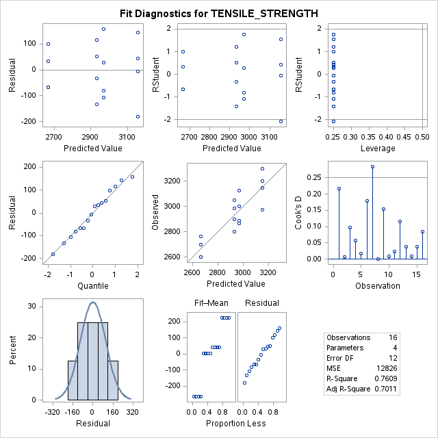

Example Oneway ANOVA Portland Cement Data

The GLM Procedure

| Levene's Test for Homogeneity of TENSILE_STRENGTH Variance ANOVA of Squared Deviations from Group Means Source | Levene's Test for Homogeneity of TENSILE_STRENGTH Variance ANOVA of Squared Deviations from Group Means DF | Levene's Test for Homogeneity of TENSILE_STRENGTH Variance ANOVA of Squared Deviations from Group Means Sum of Squares | Levene's Test for Homogeneity of TENSILE_STRENGTH Variance ANOVA of Squared Deviations from Group Means Mean Square | Levene's Test for Homogeneity of TENSILE_STRENGTH Variance ANOVA of Squared Deviations from Group Means F Value | Levene's Test for Homogeneity of TENSILE_STRENGTH Variance ANOVA of Squared Deviations from Group Means Pr > F |
| --- | --- | --- | --- | --- | --- |
| PORTLAND_CEMENT | 3 | 1.6992E8 | 56639998 | 0.52 | 0.6743 |
| Error | 12 | 1.2985E9 | 1.082E8 |  |  |

| Welch's ANOVA for TENSILE_STRENGTH Source | Welch's ANOVA for TENSILE_STRENGTH DF | Welch's ANOVA for TENSILE_STRENGTH F Value | Welch's ANOVA for TENSILE_STRENGTH Pr > F |
| --- | --- | --- | --- |
| PORTLAND_CEMENT | 3.0000 | 13.05 | 0.0037 |
| Error | 6.5400 |  |  |

Example Oneway ANOVA Portland Cement Data

The GLM Procedure

| Level of PORTLAND_CEMENT | N | TENSILE_STRENGTH Mean | TENSILE_STRENGTH Std Dev |
| --- | --- | --- | --- |
| 1 | 4 | 2971.00000 | 120.557040 |
| 2 | 4 | 3156.25000 | 135.976407 |
| 3 | 4 | 2933.75000 | 108.272419 |
| 4 | 4 | 2666.25000 | 80.970674 |

Example Oneway ANOVA Portland Cement Data

The GLIMMIX Procedure

| Model Information |  |
| --- | --- |
| Data Set | WORK.PORTLAND_CEMENT_CRD |
| Response Variable | TENSILE_STRENGTH |
| Response Distribution | Gaussian |
| Link Function | Identity |
| Variance Function | Default |
| Variance Matrix | Diagonal |
| Estimation Technique | Restricted Maximum Likelihood |
| Degrees of Freedom Method | Residual |

| Class Level Information Class | Class Level Information Levels | Class Level Information Values |
| --- | --- | --- |
| PORTLAND_CEMENT | 4 | 1 2 3 4 |

| Number of Observations Read | 16 |
| --- | --- |
| Number of Observations Used | 16 |

| Dimensions |  |
| --- | --- |
| Covariance Parameters | 1 |
| Columns in X | 5 |
| Columns in Z | 0 |
| Subjects (Blocks in V) | 1 |
| Max Obs per Subject | 16 |

| Optimization Information |  |
| --- | --- |
| Optimization Technique | None |
| Parameters | 5 |
| Lower Boundaries | 1 |
| Upper Boundaries | 0 |
| Fixed Effects | Not Profiled |

| Fit Statistics |  |
| --- | --- |
| -2 Res Log Likelihood | 153.11 |
| AIC (smaller is better) | 163.11 |
| AICC (smaller is better) | 173.11 |
| BIC (smaller is better) | 165.53 |
| CAIC (smaller is better) | 170.53 |
| HQIC (smaller is better) | 162.21 |
| Pearson Chi-Square | 153908.3 |
| Pearson Chi-Square / DF | 12825.69 |

| Type III Tests of Fixed Effects Effect | Type III Tests of Fixed Effects Num DF | Type III Tests of Fixed Effects Den DF | Type III Tests of Fixed Effects F Value | Type III Tests of Fixed Effects Pr > F |
| --- | --- | --- | --- | --- |
| PORTLAND_CEMENT | 3 | 12 | 12.73 | 0.0005 |

Example Oneway ANOVA Portland Cement Data

The UNIVARIATE Procedure

Variable: SRESID (Studentized Residual)

| Moments |  |  |  |
| --- | --- | --- | --- |
| N | 16 | Sum Weights | 16 |
| Mean | 0 | Sum Observations | 0 |
| Std Deviation | 1.03279556 | Variance | 1.06666667 |
| Skewness | -0.0703579 | Kurtosis | -0.9180531 |
| Uncorrected SS | 16 | Corrected SS | 16 |
| Coeff Variation | . | Std Error Mean | 0.25819889 |

| Basic Statistical Measures Location | Basic Statistical Measures Location | Basic Statistical Measures Variability | Basic Statistical Measures Variability |
| --- | --- | --- | --- |
| Mean | 0.00000 | Std Deviation | 1.03280 |
| Median | 0.11598 | Variance | 1.06667 |
| Mode | -0.67548 | Range | 3.45899 |
|  |  | Interquartile Range | 1.51538 |

| Tests for Location: Mu0=0 Test | Tests for Location: Mu0=0 Statistic | Tests for Location: Mu0=0 Statistic | Tests for Location: Mu0=0 p Value | Tests for Location: Mu0=0 p Value |
| --- | --- | --- | --- | --- |
| Student's t | t | 0 | Pr > \|t\| | 1.0000 |
| Sign | M | 0 | Pr >= \|M\| | 1.0000 |
| Signed Rank | S | -0.5 | Pr >= \|S\| | 0.9898 |

| Tests for Normality Test | Tests for Normality Statistic | Tests for Normality Statistic | Tests for Normality p Value | Tests for Normality p Value |
| --- | --- | --- | --- | --- |
| Shapiro-Wilk | W | 0.970457 | Pr < W | 0.8460 |
| Kolmogorov-Smirnov | D | 0.118455 | Pr > D | >0.1500 |
| Cramer-von Mises | W-Sq | 0.028596 | Pr > W-Sq | >0.2500 |
| Anderson-Darling | A-Sq | 0.185503 | Pr > A-Sq | >0.2500 |

| Quantiles (Definition 5) Level | Quantiles (Definition 5) Quantile |
| --- | --- |
| 100% Max | 1.610965 |
| 99% | 1.610965 |
| 95% | 1.610965 |
| 90% | 1.465672 |
| 75% Q3 | 0.764699 |
| 50% Median | 0.115979 |
| 25% Q1 | -0.750679 |
| 10% | -1.363713 |
| 5% | -1.848022 |
| 1% | -1.848022 |
| 0% Min | -1.848022 |

| Extreme Observations Lowest Value | Extreme Observations Lowest Obs | Extreme Observations Highest Value | Extreme Observations Highest Obs |
| --- | --- | --- | --- |
| -1.848022 | 7 | 0.522544 | 11 |
| -1.363713 | 9 | 1.006853 | 16 |
| -1.080774 | 3 | 1.185283 | 12 |
| -0.825875 | 4 | 1.465672 | 6 |
| -0.675484 | 15 | 1.610965 | 1 |

Example Oneway ANOVA Portland Cement Data

The UNIVARIATE Procedure

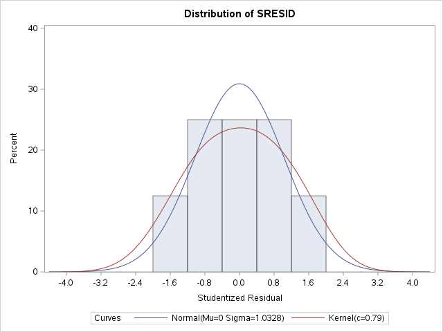

Example Oneway ANOVA Portland Cement Data

The UNIVARIATE Procedure

Fitted Normal Distribution for SRESID (Studentized Residual)

| Parameters for Normal Distribution Parameter | Parameters for Normal Distribution Symbol | Parameters for Normal Distribution Estimate |
| --- | --- | --- |
| Mean | Mu | 0 |
| Std Dev | Sigma | 1.032796 |

| Goodness-of-Fit Tests for Normal Distribution Test | Goodness-of-Fit Tests for Normal Distribution Statistic | Goodness-of-Fit Tests for Normal Distribution Statistic | Goodness-of-Fit Tests for Normal Distribution p Value | Goodness-of-Fit Tests for Normal Distribution p Value |
| --- | --- | --- | --- | --- |
| Kolmogorov-Smirnov | D | 0.11845516 | Pr > D | >0.150 |
| Cramer-von Mises | W-Sq | 0.02859638 | Pr > W-Sq | >0.250 |
| Anderson-Darling | A-Sq | 0.18550316 | Pr > A-Sq | >0.250 |

| Quantiles for Normal Distribution Percent | Quantiles for Normal Distribution Quantile Observed | Quantiles for Normal Distribution Quantile Estimated |
| --- | --- | --- |
| 1.0 | -1.84802 | -2.40264 |
| 5.0 | -1.84802 | -1.69880 |
| 10.0 | -1.36371 | -1.32358 |
| 25.0 | -0.75068 | -0.69661 |
| 50.0 | 0.11598 | 0.00000 |
| 75.0 | 0.76470 | 0.69661 |
| 90.0 | 1.46567 | 1.32358 |
| 95.0 | 1.61097 | 1.69880 |
| 99.0 | 1.61097 | 2.40264 |

Example Oneway ANOVA Portland Cement Data

The GLM Procedure

| Class Level Information Class | Class Level Information Levels | Class Level Information Values |
| --- | --- | --- |
| PORTLAND_CEMENT | 4 | 1 2 3 4 |

| Number of Observations Read | 16 |
| --- | --- |
| Number of Observations Used | 16 |

Example Oneway ANOVA Portland Cement Data

The GLM Procedure

Dependent Variable: TENSILE_STRENGTH Tensile Strength (lb/sq.inch)

| Source | DF | Sum of Squares | Mean Square | F Value | Pr > F |
| --- | --- | --- | --- | --- | --- |
| Model | 3 | 489740.1875 | 163246.7292 | 12.73 | 0.0005 |
| Error | 12 | 153908.2500 | 12825.6875 |  |  |
| Corrected Total | 15 | 643648.4375 |  |  |  |

| R-Square | Coeff Var | Root MSE | TENSILE_STRENGTH Mean |
| --- | --- | --- | --- |
| 0.760881 | 3.862817 | 113.2506 | 2931.813 |

| Source | DF | Type I SS | Mean Square | F Value | Pr > F |
| --- | --- | --- | --- | --- | --- |
| PORTLAND_CEMENT | 3 | 489740.1875 | 163246.7292 | 12.73 | 0.0005 |

| Source | DF | Type III SS | Mean Square | F Value | Pr > F |
| --- | --- | --- | --- | --- | --- |
| PORTLAND_CEMENT | 3 | 489740.1875 | 163246.7292 | 12.73 | 0.0005 |

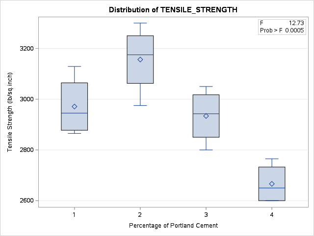

Example Oneway ANOVA Portland Cement Data

The GLM Procedure

| Levene's Test for Homogeneity of TENSILE_STRENGTH Variance ANOVA of Squared Deviations from Group Means Source | Levene's Test for Homogeneity of TENSILE_STRENGTH Variance ANOVA of Squared Deviations from Group Means DF | Levene's Test for Homogeneity of TENSILE_STRENGTH Variance ANOVA of Squared Deviations from Group Means Sum of Squares | Levene's Test for Homogeneity of TENSILE_STRENGTH Variance ANOVA of Squared Deviations from Group Means Mean Square | Levene's Test for Homogeneity of TENSILE_STRENGTH Variance ANOVA of Squared Deviations from Group Means F Value | Levene's Test for Homogeneity of TENSILE_STRENGTH Variance ANOVA of Squared Deviations from Group Means Pr > F |
| --- | --- | --- | --- | --- | --- |
| PORTLAND_CEMENT | 3 | 1.6992E8 | 56639998 | 0.52 | 0.6743 |
| Error | 12 | 1.2985E9 | 1.082E8 |  |  |

| Welch's ANOVA for TENSILE_STRENGTH Source | Welch's ANOVA for TENSILE_STRENGTH DF | Welch's ANOVA for TENSILE_STRENGTH F Value | Welch's ANOVA for TENSILE_STRENGTH Pr > F |
| --- | --- | --- | --- |
| PORTLAND_CEMENT | 3.0000 | 13.05 | 0.0037 |
| Error | 6.5400 |  |  |

Example Oneway ANOVA Portland Cement Data

The GLM Procedure

| Level of PORTLAND_CEMENT | N | TENSILE_STRENGTH Mean | TENSILE_STRENGTH Std Dev |
| --- | --- | --- | --- |
| 1 | 4 | 2971.00000 | 120.557040 |
| 2 | 4 | 3156.25000 | 135.976407 |
| 3 | 4 | 2933.75000 | 108.272419 |
| 4 | 4 | 2666.25000 | 80.970674 |

Example Oneway ANOVA Portland Cement Data

The GLM Procedure

Least Squares Means

| PORTLAND_CEMENT | TENSILE_STRENGTH LSMEAN | LSMEAN Number |
| --- | --- | --- |
| 1 | 2971.00000 | 1 |
| 2 | 3156.25000 | 2 |
| 3 | 2933.75000 | 3 |
| 4 | 2666.25000 | 4 |

| Least Squares Means for effect PORTLAND_CEMENT Pr > \|t\| for H0: LSMean(i)=LSMean(j) Dependent Variable: TENSILE_STRENGTH i/j | Least Squares Means for effect PORTLAND_CEMENT Pr > \|t\| for H0: LSMean(i)=LSMean(j) Dependent Variable: TENSILE_STRENGTH 1 | Least Squares Means for effect PORTLAND_CEMENT Pr > \|t\| for H0: LSMean(i)=LSMean(j) Dependent Variable: TENSILE_STRENGTH 2 | Least Squares Means for effect PORTLAND_CEMENT Pr > \|t\| for H0: LSMean(i)=LSMean(j) Dependent Variable: TENSILE_STRENGTH 3 | Least Squares Means for effect PORTLAND_CEMENT Pr > \|t\| for H0: LSMean(i)=LSMean(j) Dependent Variable: TENSILE_STRENGTH 4 |
| --- | --- | --- | --- | --- |
| 1 |  | 0.0392 | 0.6501 | 0.0025 |
| 2 | 0.0392 |  | 0.0167 | <.0001 |
| 3 | 0.6501 | 0.0167 |  | 0.0059 |
| 4 | 0.0025 | <.0001 | 0.0059 |  |

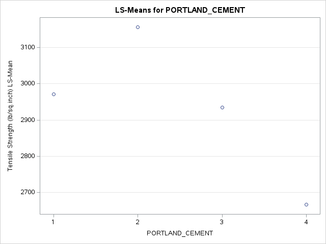

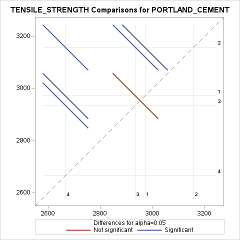

Note:To ensure overall protection level, only probabilities associated with pre-planned comparisons should be used.